# Machine Learning for Epi: Assignment 9

2023-03-28

### Set up: Partition data into training/testing

The code chunks below loads and subsets the data, and partitions the data into a 70/30 training/testing split.

```r
data ("NHANES")

keep.var<-names(NHANES) %in% c("Age", "Race1", "Education", "Poverty", "Weight", "Height", "Pulse", "Diabetes", "BMI", "PhysActive", "Smoke100", "BPSysAve", "BPDiaAve", "TotChol")

NHANES.subset<-NHANES[keep.var]

#Remove missings and then remove duplicates
NHANES.subset<-na.omit(NHANES.subset)
NHANES.subset<-unique(NHANES.subset)

#Check distributions
summary(NHANES.subset)
```

```
##       Age             Race1               Education       Poverty
##  Min.   :20.00   Black   : 531   8th Grade     : 266   Min.   :0.000
##  1st Qu.:32.00   Hispanic: 258   9 - 11th Grade: 511   1st Qu.:1.240
##  Median :46.00   Mexican : 390   High School   : 828   Median :2.635
##  Mean   :47.25   White   :2390   Some College  :1194   Mean   :2.783
##  3rd Qu.:60.00   Other   : 311   College Grad  :1081   3rd Qu.:4.650
##  Max.   :80.00                                         Max.   :5.000
##      Weight           Height           BMI            Pulse
##  Min.   : 37.00   Min.   :139.9   Min.   :15.02   Min.   : 40.00
##  1st Qu.: 67.50   1st Qu.:161.3   1st Qu.:24.20   1st Qu.: 64.00
##  Median : 79.80   Median :168.6   Median :27.80   Median : 72.00
##  Mean   : 82.55   Mean   :168.7   Mean   :28.95   Mean   : 72.45
##  3rd Qu.: 93.90   3rd Qu.:175.8   3rd Qu.:32.34   3rd Qu.: 80.00
##  Max.   :230.70   Max.   :200.4   Max.   :81.25   Max.   :128.00
##     BPSysAve      BPDiaAve         TotChol       Diabetes   PhysActive
##  Min.   : 78   Min.   :  0.00   Min.   : 1.530   No :3437   No :1850
##  1st Qu.:109   1st Qu.: 63.00   1st Qu.: 4.290   Yes: 443   Yes:2030
##  Median :119   Median : 70.00   Median : 4.990
##  Mean   :121   Mean   : 69.93   Mean   : 5.051
##  3rd Qu.:130   3rd Qu.: 78.00   3rd Qu.: 5.690
##  Max.   :226   Max.   :116.00   Max.   :13.650
##  Smoke100
##  No :2161
##  Yes:1719
##
##
##
##
```

Our resulting dataset contains 3880 observations of 14 features, with 1 containing our binary outcome variable, `Diabetes`. Based on the summary, we can see that the distribution of diabetes is quite unbalanced, with a 11.4% prevalence of cases.

```r
set.seed(123)

training.data<-createDataPartition(NHANES.subset$Diabetes, p=0.7, list=F)
train.data<-NHANES.subset[training.data, ]
test.data<-NHANES.subset[-training.data, ]
```

We will fit 3 prediction models to generate a clinical risk score for diabetes. (feature name: `Diabetes`).

The best tune for hyperparameters will be selected based on accuracy, and the three models will be compared for accuracy in the training set.

### Model fitting

#### Model 1: Random Forest

For the random forest, we will try 3 different values of mtry. To save computational time, we will set ntree to 100, as in Exercise 8, we did not see much of an improvement in model accuracy when increasing the number of trees.

```r
set.seed(123)

# Try mtry of all, half of all, sqrt of all,
feat.count <- c((ncol(train.data)-1), (ncol(train.data)-1)/2, sqrt(ncol(train.data)-1))
grid.rf <- expand.grid(mtry = feat.count)

#Set 5-fold cross-validation and upsample
control.obj = trainControl(method = "cv", number = 5, sampling = "up")

rf.nhanes.bt <- train(Diabetes~., data=train.data, method="rf", trControl=control.obj, metric="Accuracy", tuneGrid = grid.rf, importance=TRUE, ntree=100)

confusionMatrix(rf.nhanes.bt)
```

```
## Cross-Validated (5 fold) Confusion Matrix
##
## (entries are percentual average cell counts across resamples)
##
##           Reference
## Prediction   No  Yes
##        No  86.4  9.6
##        Yes  2.1  1.8
##
##  Accuracy (average) : 0.8826
```

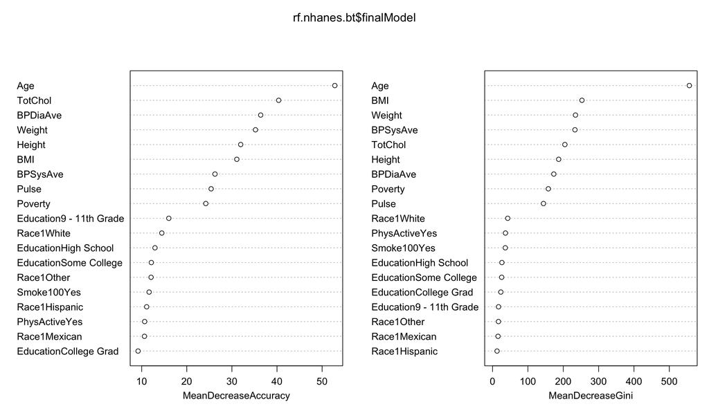

```r
varImpPlot(rf.nhanes.bt$finalModel)
```

```r
rf.nhanes.bt$results %>% kbl(digits = 4) %>%
  kable_classic("striped")
```

| mtry | Accuracy | Kappa | AccuracySD | KappaSD |
| --- | --- | --- | --- | --- |
| 3.6056 | 0.8826 | 0.1892 | 0.0055 | 0.0600 |
| 6.5000 | 0.8782 | 0.1939 | 0.0049 | 0.0458 |
| 13.0000 | 0.8679 | 0.1983 | 0.0145 | 0.0758 |

#### Model 2: Support Vector Classifier

For SVC, we will vary the cost parameter using a vector of values ranging from 0.0001 to 0.001, as we saw in the class exercise that smaller values of C were found to improve model accuracy.

```r
set.seed(123)

control.obj <- trainControl(method="cv", number = 5, sampling = "up", classProbs = TRUE)

#Repeat expanding the grid search
svc.nhanes <- train(Diabetes ~ ., data=train.data, method = "svmLinear", trControl=control.obj, preProcess=c("center", "scale"), probability = TRUE, tuneGrid = expand.grid(C = seq(0.0001,0.001, length = 5)))

confusionMatrix(svc.nhanes)
```

```
## Cross-Validated (5 fold) Confusion Matrix
##
## (entries are percentual average cell counts across resamples)
##
##           Reference
## Prediction   No  Yes
##        No  67.3  3.5
##        Yes 21.2  8.0
##
##  Accuracy (average) : 0.753
```

```r
svc.nhanes$results %>% kbl(digits = 5) %>%
  kable_classic("striped")
```

| C | Accuracy | Kappa | AccuracySD | KappaSD |
| --- | --- | --- | --- | --- |
| 0.00010 | 0.75304 | 0.27386 | 0.02153 | 0.03697 |
| 0.00032 | 0.72028 | 0.25892 | 0.01413 | 0.04036 |
| 0.00055 | 0.73794 | 0.26578 | 0.00705 | 0.02632 |
| 0.00078 | 0.74310 | 0.28047 | 0.01316 | 0.03410 |
| 0.00100 | 0.74642 | 0.28098 | 0.00930 | 0.02129 |

#### Model 3: Logistic Regression

For our baseline logistic regression model, we will train the data using the same train control parameters as above.

```r
set.seed(123)

control.obj <- trainControl(method="cv", number = 5, sampling = "up")

logit.nhanes <- train(Diabetes~., data = train.data, method = "glm", family = "binomial",
                    preProcess = c("center", "scale"), trControl = control.obj)

logit.nhanes$results %>%
  kbl(digits = 4) %>%
  kable_classic("striped")
```

| parameter | Accuracy | Kappa | AccuracySD | KappaSD |
| --- | --- | --- | --- | --- |
| none | 0.7449 | 0.2873 | 0.0129 | 0.0199 |

```r
coef(logit.nhanes$finalModel) %>% cbind() %>%
  kbl(digits = 4) %>%
  kable_classic("striped")
```

|  | . |
| --- | --- |
| (Intercept) | -0.0300 |
| Age | 1.2712 |
| Race1Hispanic | -0.0019 |
| Race1Mexican | 0.0780 |
| Race1White | -0.3066 |
| Race1Other | 0.2074 |
| `Education9 - 11th Grade` | -0.1721 |
| `EducationHigh School` | -0.1382 |
| `EducationSome College` | 0.0035 |
| `EducationCollege Grad` | -0.0780 |
| Poverty | -0.2201 |
| Weight | -1.8477 |
| Height | 1.0232 |
| BMI | 2.4775 |
| Pulse | 0.2527 |
| BPSysAve | 0.1692 |
| BPDiaAve | 0.0011 |
| TotChol | -0.1934 |
| PhysActiveYes | -0.0009 |
| Smoke100Yes | 0.2308 |

```r
confusionMatrix(logit.nhanes)
```

```
## Cross-Validated (5 fold) Confusion Matrix
##
## (entries are percentual average cell counts across resamples)
##
##           Reference
## Prediction   No  Yes
##        No  65.7  2.7
##        Yes 22.8  8.8
##
##  Accuracy (average) : 0.7449
```

### Output predicted probabilities from each of the three models applied within the testing set.

```r
#Predict in test-set and output probabilities
rf.probs<-predict(rf.nhanes.bt, test.data, type="prob")

#Pull out predicted probabilities for Diabetes=Yes
rf.pp<-rf.probs[,2]

svc.probs<-predict(svc.nhanes,test.data, type="prob")
svc.pp<-svc.probs[,2]

#Predict in test-set using response type
logit.probs<-predict(logit.nhanes, test.data, type="prob")
logit.pp<-logit.probs[,2]
```

### Plot and compare calibration curves across the three algorithms.

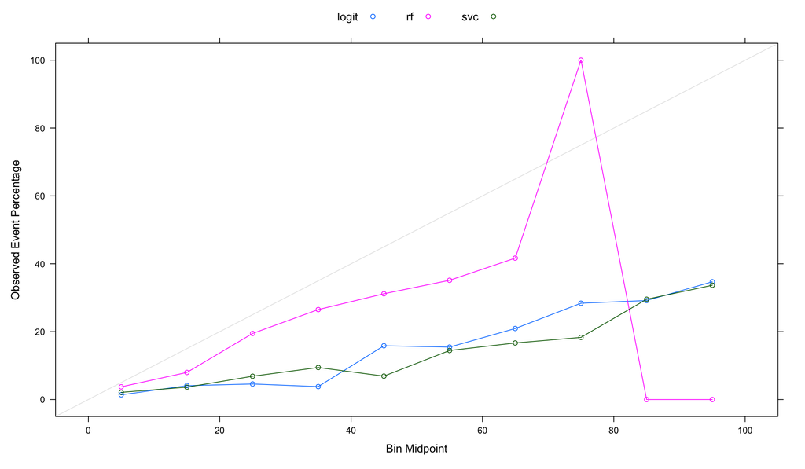

```r
pred.prob<-data.frame(Class=test.data$Diabetes, logit=logit.pp, rf=rf.pp, svc=svc.pp)

calplot<-(calibration(Class ~ logit+rf+svc, data=pred.prob, class="Yes", cuts=10))

xyplot(calplot, auto.key=list(columns=3))
```

Based on the pre-calibration curves, we can see that all 3 models tend to overestimate risk of diabetes across most risk score values. The exception is for the RF model, which appears to “spike” at a point in the curve, indicating that at a risk score of 70%, the model underestimates diabetes risk at this level.

### Calibrate the probabilities from SVC and RF

The code chunk below partition testing data into 2 sets: set to train calibration and then set to evaluate results. We will use Platt’s Scaling to train a logistic regression model on the outputs of our classifier.

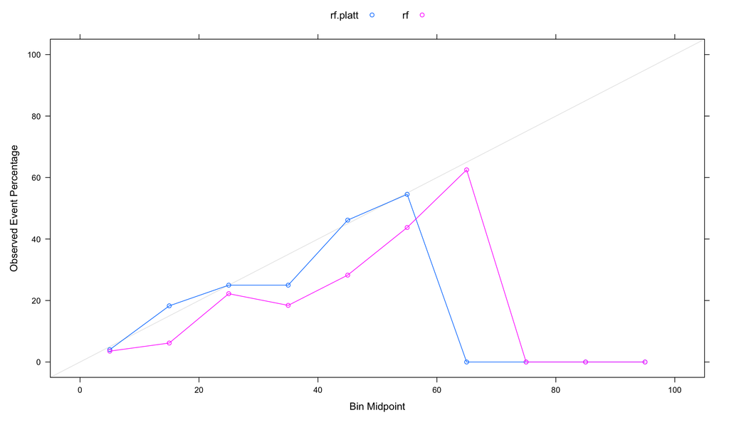

```r
set.seed(123)

cal.data.index<-test.data$Diabetes%>% createDataPartition(p=0.5, list=F)
cal.data<-test.data[cal.data.index, ]
final.test.data<-test.data[-cal.data.index, ]

#Calibration of RF

#Predict on test-set without scaling to obtain raw pred prob in test set
rf.probs.nocal<-predict(rf.nhanes.bt, final.test.data, type="prob")
rf.pp.nocal<-rf.probs.nocal[,2]

#Apply model developed on training data to calibration dataset to obtain predictions
rf.probs.cal<-predict(rf.nhanes.bt, cal.data, type="prob")
rf.pp.cal<-rf.probs.cal[,2]

#Add to dataset with actual values from calibration data
calibrf.data.frame<-data.frame(rf.pp.cal, cal.data$Diabetes)
colnames(calibrf.data.frame)<-c("x", "y")

#Use logistic regression to model predicted probabilities from calibration data to actual vales
calibrf.model<-glm(y ~ x, data=calibrf.data.frame, family = binomial)

#Apply calibration model above to raw predicted probabilities from test set
data.test.rf<-data.frame(rf.pp.nocal)
colnames(data.test.rf)<-c("x")
platt.data.rf<-predict(calibrf.model, data.test.rf, type="response")

platt.prob.rf<-data.frame(Class=final.test.data$Diabetes, rf.platt=platt.data.rf, rf=rf.pp.nocal)

calplot.rf<-(calibration(Class ~ rf.platt+rf, data=platt.prob.rf, class="Yes", cuts=10))
xyplot(calplot.rf, auto.key=list(columns=2))
```

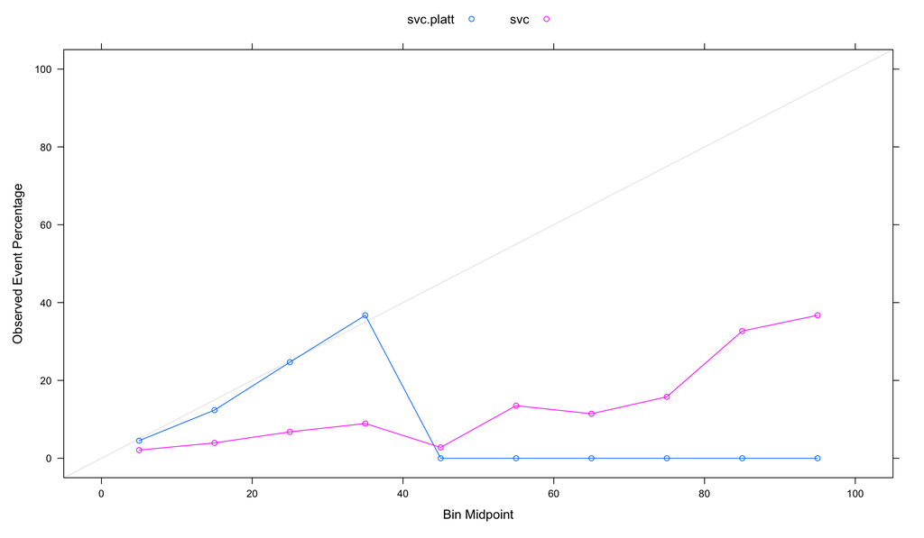

```r
#Calibration of SVC

#Predict on test-set without scaling
svc.nocal<-predict(svc.nhanes,final.test.data, type="prob")
svc.pp.nocal<-svc.nocal[,2]

#Apply model developed on training data to calibration dataset to obtain predictions
svc.cal<-predict(svc.nhanes,cal.data, type="prob")
svc.pp.cal<-svc.cal[,2]

#Add to dataset with actual values from calibration data

calib.data.frame<-data.frame(svc.pp.cal, cal.data$Diabetes)
colnames(calib.data.frame)<-c("x", "y")
calib.model<-glm(y ~ x, data=calib.data.frame, family = binomial)

#Predict on test set using model developed in calibration
data.test<-data.frame(svc.pp.nocal)
colnames(data.test)<-c("x")
platt.data<-predict(calib.model, data.test, type="response")

platt.prob<-data.frame(Class=final.test.data$Diabetes, svc.platt=platt.data, svc=svc.pp.nocal)

calplot<-(calibration(Class ~ svc.platt+svc, data=platt.prob, class="Yes", cuts=10))
xyplot(calplot, auto.key=list(columns=2))
```

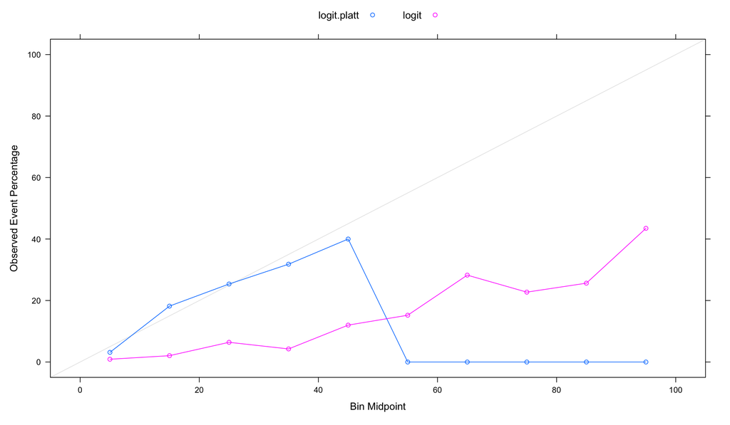

```r
#Calibration of logistic regression

#Predict on test-set without scaling
logit.nocal<-predict(logit.nhanes,final.test.data, type="prob")
logit.pp.nocal<-logit.nocal[,2]

#Apply model developed on training data to calibration dataset to obtain predictions
logit.cal<-predict(logit.nhanes,cal.data, type="prob")
logit.pp.cal<-logit.cal[,2]

#Add to dataset with actual values from calibration data

calib.data.frame<-data.frame(logit.pp.cal, cal.data$Diabetes)
colnames(calib.data.frame)<-c("x", "y")
calib.model<-glm(y ~ x, data=calib.data.frame, family = binomial)

#Predict on test set using model developed in calibration
data.test<-data.frame(logit.pp.nocal)
colnames(data.test)<-c("x")
platt.data<-predict(calib.model, data.test, type="response")

platt.prob<-data.frame(Class=final.test.data$Diabetes, logit.platt=platt.data, logit=logit.pp.nocal)

calplot<-(calibration(Class ~ logit.platt+logit, data=platt.prob, class="Yes", cuts=10))
xyplot(calplot, auto.key=list(columns=2))
```

#### Final model choice

By comparing the pre-post calibration curves across all 3 models, I would select the RF model among the 3. This is because the RF model reports the highest accuracy on the training data, and after Platt’s scaling, the model seems to adequately estimate true diabetes risk for the largest range of risk scores compared to the other 2 models. However, I would only argue that the RF model would only be optimal for clinical application among those with low risk scores for diabetes (0 - 60%), as we can see that the calibration curve levels off very quickly for risk scores greater than 60%. If we were to apply this model for patients with very high diabetes risk, it would result in gross overestimation of their true diabetes risk, leading to potential harms for patients who may receive unnecessary interventions as a result of misclassification.

#### Additional evaluation

Before being applied to a clinical setting, I would like to verify whether the data used to train this model adequately captures the diversity and heterogeneity of patient populations that the algorithm would be applied to in a real-world setting. This would address potential issues where the model would perpetuate biases against certain patient populations based on specific features. This could be done by assessing prediction performance of the model on different datasets from different healthcare settings, and consulting with clinicians, healthcare pracitioners, and subject knowledge experts to evaluate the algorithm’s performance before being applied in a clinical setting.